# Reproducible Research: Peer Assessment 1

## Loading and preprocessing the data

```r
act <- read.csv("activity.csv")
```

## What is mean total number of steps taken per day?

1. Make a histogram of the total number of steps taken each day

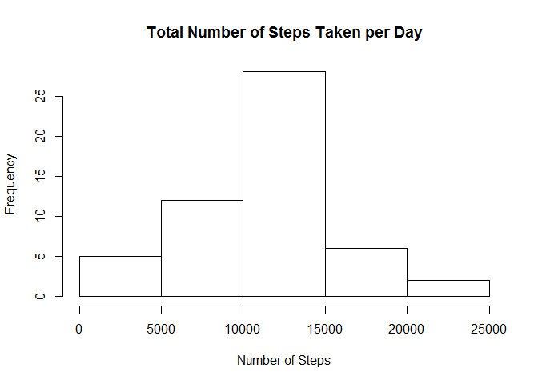

```r
act_sum_date <- aggregate(steps ~ date, data=act, sum)
hist(act_sum_date$steps, main="Total Number of Steps Taken per Day", xlab="Number of Steps")
```

2. Calculate and report the mean and median total number of steps taken per day

```r
act_mean_date <- aggregate(steps ~ date, data=act, mean)
colnames(act_mean_date) <- c("date", "average_steps")
act_mean_date
```

```
##          date average_steps
## 1  2012-10-02     0.4375000
## 2  2012-10-03    39.4166667
## 3  2012-10-04    42.0694444
## 4  2012-10-05    46.1597222
## 5  2012-10-06    53.5416667
## 6  2012-10-07    38.2465278
## 7  2012-10-09    44.4826389
## 8  2012-10-10    34.3750000
## 9  2012-10-11    35.7777778
## 10 2012-10-12    60.3541667
## 11 2012-10-13    43.1458333
## 12 2012-10-14    52.4236111
## 13 2012-10-15    35.2048611
## 14 2012-10-16    52.3750000
```

[output cut: 39 more lines]

```r
act_median_date <- aggregate(steps ~ date, data=act, median)
colnames(act_median_date) <- c("date", "median_steps")
act_median_date
```

```
##          date median_steps
## 1  2012-10-02            0
## 2  2012-10-03            0
## 3  2012-10-04            0
## 4  2012-10-05            0
## 5  2012-10-06            0
## 6  2012-10-07            0
## 7  2012-10-09            0
## 8  2012-10-10            0
## 9  2012-10-11            0
## 10 2012-10-12            0
## 11 2012-10-13            0
## 12 2012-10-14            0
## 13 2012-10-15            0
## 14 2012-10-16            0
```

[output cut: 39 more lines]

## What is the average daily activity pattern?

1. Make a time series plot (i.e. type = “l”) of the 5-minute interval (x-axis) and the average number of steps taken, averaged across all days (y-axis)

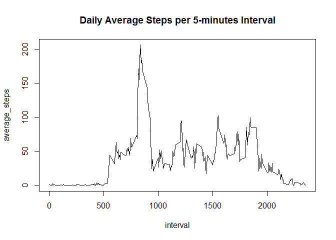

```r
act_mean_interval <- aggregate(steps ~ interval, data=act, mean)
colnames(act_mean_interval) <- c("interval", "average_steps")

plot(act_mean_interval, type="l", main="Daily Average Steps per 5-minutes Interval")
```

2. Which 5-minute interval, on average across all the days in the dataset, contains the maximum number of steps?

```r
subset(act_mean_interval, average_steps==max(act_mean_interval$average_steps))
```

```
##     interval average_steps
## 104      835      206.1698
```

## Imputing missing values

1. Calculate and report the total number of missing values in the dataset.

```r
nrow(act[is.na(act$steps),])
```

```
## [1] 2304
```

2. Devise a strategy for filling in all of the missing values in the dataset.  
   Missing values will be replaced with the average steps of the interval.
3. Create a new dataset that is equal to the original dataset but with the missing data filled in.

```r
act_na <- act[is.na(act$steps),]
act_na_average <- merge(act_na, act_mean_interval)
act_na_average$steps <- act_na_average$average_steps
act_filled <- rbind(act_na_average[, c("steps", "date", "interval")], act[!is.na(act$steps), ])
```

4. Make a histogram of the total number of steps taken each day and Calculate and report the mean and median total number of steps taken per day.

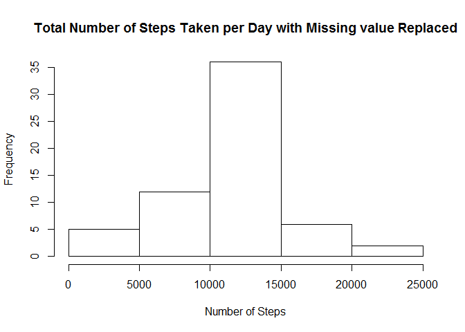

```r
act_filled_sum_date <- aggregate(steps ~ date, data=act_filled, sum)
hist(act_filled_sum_date$steps, main="Total Number of Steps Taken per Day with Missing value Replaced", xlab="Number of Steps")
```

```r
act_filled_mean_date <- aggregate(steps ~ date, data=act_filled, mean)
colnames(act_filled_mean_date) <- c("date", "average_steps")
act_filled_mean_date
```

```
##          date average_steps
## 1  2012-10-01    37.3825996
## 2  2012-10-02     0.4375000
## 3  2012-10-03    39.4166667
## 4  2012-10-04    42.0694444
## 5  2012-10-05    46.1597222
## 6  2012-10-06    53.5416667
## 7  2012-10-07    38.2465278
## 8  2012-10-08    37.3825996
## 9  2012-10-09    44.4826389
## 10 2012-10-10    34.3750000
## 11 2012-10-11    35.7777778
## 12 2012-10-12    60.3541667
## 13 2012-10-13    43.1458333
## 14 2012-10-14    52.4236111
```

[output cut: 47 more lines]

```r
act_filled_median_date <- aggregate(steps ~ date, data=act_filled, median)
colnames(act_filled_median_date) <- c("date", "median_steps")
act_filled_median_date
```

```
##          date median_steps
## 1  2012-10-01     34.11321
## 2  2012-10-02      0.00000
## 3  2012-10-03      0.00000
## 4  2012-10-04      0.00000
## 5  2012-10-05      0.00000
## 6  2012-10-06      0.00000
## 7  2012-10-07      0.00000
## 8  2012-10-08     34.11321
## 9  2012-10-09      0.00000
## 10 2012-10-10      0.00000
## 11 2012-10-11      0.00000
## 12 2012-10-12      0.00000
## 13 2012-10-13      0.00000
## 14 2012-10-14      0.00000
```

[output cut: 47 more lines]

## Are there differences in activity patterns between weekdays and weekends?

1. Create a new factor variable in the dataset with two levels - “weekday” and “weekend” indicating whether a given date is a weekday or weekend day.

```r
act_filled_weekdays <- transform(act_filled, day=weekdays(as.Date(date)))
weekday <- data.frame(day=c("Saturday", "Sunday", "Monday", "Tuesday", "Wednesday", "Thursday", "Friday"), weekday=c(rep("weekend", 2), rep("weekday", 5)))
act_filled_weekdays <- merge(weekday, act_filled_weekdays)
```

2. Make a panel plot containing a time series plot (i.e. type = “l”) of the 5-minute interval (x-axis) and the average number of steps taken, averaged across all weekday days or weekend days (y-axis).

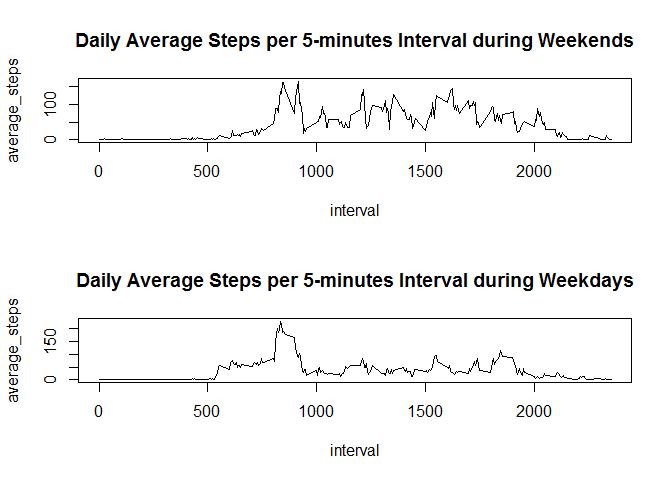

```r
act_filled_weekdays_mean <- aggregate(steps ~ weekday + interval, data=act_filled_weekdays, mean)
colnames(act_filled_weekdays_mean) <- c("weekday", "interval", "average_steps")
par(mfrow=c(2, 1))
plot(act_filled_weekdays_mean[act_filled_weekdays_mean$weekday=="weekend", c("interval", "average_steps")], type="l", main="Daily Average Steps per 5-minutes Interval during Weekends")
plot(act_filled_weekdays_mean[act_filled_weekdays_mean$weekday=="weekday", c("interval", "average_steps")], type="l", main="Daily Average Steps per 5-minutes Interval during Weekdays")
```